# SM1. Data filtering and outlier removal

Supplementary Material for ‘The overlooked effect of amplitude on within-speaker vowel variation’

Joshua Wilson Black, Jen Hay, Lynn Clark, James Brand

17 March, 2023

# 1 Overview

This worksheet presents the data preprocessing steps carried out for the project.

We cover, in turn:

1. data filtering
2. outlier removal,
3. checking for overlapping vowel spaces, and
4. description of the resulting data.

Throughout we use packages in the `tidyverse`. The workflow we adopt closely follows [Brand et al. (2021)](https://doi.org/10.1016/j.wocn.2021.101096).

**NB:** Code blocks in this markdown which output files have been set to not evaluate. This is to prevent writing over data while tidying the document. In order to follow our analysis, you may need to change `eval=FALSE` to `eval=TRUE` in some code blocks. These will be noted when they appear.

# 2 Libraries and Raw Data

```r
# Tidyverse and friends
library(tidyverse)
library(glue)
library(gganimate)
library(ggforce)
library(tidyselect)

# Flow diagrams
library(DiagrammeR)

# Filepath management.
library(here)

# Scaling and cleaning data.
library(scales)
library(janitor)
library(kableExtra)
```

The raw data comes from the QuakeBox corpus [(Clark et al, 2016](https://www.sciencedirect.com/science/article/pii/S2215039016300066), see also [this link](https://quakestudies.canterbury.ac.nz/store/collection/235) for more information and example recordings).

The corpus comprises a sociolinguistic database of audio and video recordings, where members of the public were invited to record stories of their experiences of the earthquakes that hit Christchurch, New Zealand in 2010-2011. The stories were recorded in high quality audio and video. Participants were prompted to ‘tell us your earthquake story’. The recordings took place in 2012 and were forced-aligned using the HTK aligner (Young et al., 2002), with the corpus stored on a LaBB-CAT instance [(Fromont and Hay, 2012)](https://www.aclweb.org/anthology/U12-1015/).

We carried out pitch, formant and amplitude tracking by means of LaBB-CAT’s interface with [Praat](https://www.fon.hum.uva.nl/praat/). Default settings were used:

- Formants:
  - sample point: 0.5,
  - maximum formants: 5,
  - maximum formant value (female): 5500,
  - maximum formant value (male): 5000,
  - window length: 0.025 seconds,
  - preemphasis from: 50 hertz.
- Pitch:
  - get mean, minimum, and maximum,
  - time.step: 0,
  - minimum pitch (female): 60,
  - minimum pitch (male): 30,
  - maximum pitch (female): 500,
  - maximum pitch (male): 250,
  - maximum candidates: 15,
  - silence threshold: 0.03,
  - voicing threshold (female): 0.5,
  - voicing threshold (male): 0.4,
  - octave cost: 0.01,
  - octave jump cost: 0.035,
  - voiced/unvoiced cost: 0.35,
  - window length: 0.025 seconds,
  - preemphasis from: 50 hertz.
- Amplitude (taken from word rather than vowel token):
  - minimum pitch: 100 hertz,
  - subtract mean: FALSE.

Amplitude values were only meaningful for words of length greater than 0.064 seconds.

The corpus was queried for all instances of the following vowels: dress, fleece, foot, goose, kit, lot, nurse, schwa, start, strut, thought, trap. We exclude speakers who did not grow up in New Zealand. We have anonymised the data and stored it as an `rds` file.

```r
#Raw data import
Quakebox_anonymised <- read_rds(
  here('labbcat_data', 'anonymised_data.rds')
)

# The 'count_' variables taken throughout are used to plot how many tokens are
# lost at each stage of filtering. We have to hard code the first variable as
# we cannot share the full non-anonymised data set.
count_orig <- 486073
count_load <- nrow(Quakebox_anonymised)
```

At this point it is convenient to rename variables.

```r
Quakebox_anonymised <- Quakebox_anonymised %>%
  rename(
    Speaker = speaker,
    F1_50 = F1,
    F2_50 = F2,
    Vowel = vowel
  )
```

# 3 Filtering

The anonymised data we have made publicly available has already had stopwords,[^1] words with hesitations, and tokens without transcribed words removed. Otherwise, there would be enough information to determine the identities of many of our participants. The remaining filtering steps are carried out in this worksheet.

Following Brand et al. (2021) we filter tokens with F1s above 1100. An F1 value this high suggests a tracking problem.

We also remove:

- any tokens of duration less than 0.01 or greater than 2 (seconds),
- any with missing gender information,
- any speakers with no articulation rate information,
- any instances of schwa, and
- any unstressed tokens.

```r
Quakebox_filtered <- Quakebox_anonymised %>%
  filter(
    F1_50 < 1100,
    vowel_duration >= 0.01, #filter tokens with very short or long vowel durations
    vowel_duration <= 2,
    !is.na(participant_gender), #filter speakers with missing gender
    !is.na(participant_speaker.articulation.rate),
    Vowel != "SCHWA", #remove all SCHWA tokens
    Target.stress != "0" #filter any unstressed tokens
  )

count_filter <- nrow(Quakebox_filtered)
```

We categorise following segments into labials, velars, liquids and others. We remove any vowel tokens which are followed by a liquid. NZE has vowel mergers before /l/, and postvocalic /r/ and /l/ are only variably realized with high levels of /l/-vocalization and low levels of rhoticity. We cannot accurately control for the effect on the formants of these phenomena.

```r
Quakebox_filtered <- Quakebox_filtered %>%

  # Categorise following segments
  mutate(
    following_segment = following_segment[, 1],
    following_segment_category = fct_collapse(
      as_factor(following_segment),
      labial = c('m', 'p', 'b', 'f', 'w'),
      velar = c('k', 'g', 'N'),
      liquid = c('r', 'l'),
      other_level = "other"
    )
  ) %>%

  # Filter out tokens which are followed by a liquid.
  filter(
    !following_segment_category == 'liquid'
  )

count_liquid <- nrow(Quakebox_filtered)
```

# 4 Outlier Removal

We now remove outliers. These are likely the result of errors in the force alignment or transcription process. For each speaker, and for their F1 and F2 for each vowel, we calculate the mean and standard deviation and remove tokens which have values above or below 2.5 standard deviations from the mean.

```r
#Set standard deviation limit at 2.5.
sd_limit = 2.5

vowels_all_summary <- Quakebox_filtered %>%
  # Remove tokens at +/- 2.5 standard deviations
  group_by(Speaker, Vowel) %>%
  summarise(
    #calculate the summary statistics required for the outlier removal.
    n = n(),
    mean_F1 = mean(F1_50, na.rm = TRUE),
    mean_F2 = mean(F2_50, na.rm = TRUE),
    sd_F1 = sd(F1_50, na.rm = TRUE),
    sd_F2 = sd(F2_50, na.rm = TRUE),
    # Calculate cut off values.
    max_F1 = mean(F1_50) + sd_limit*(sd(F1_50)),
    min_F1 = mean(F1_50) - sd_limit*(sd(F1_50)),
    max_F2 = mean(F2_50) + sd_limit*(sd(F2_50)),
    min_F2 = mean(F2_50) - sd_limit*(sd(F2_50))
  )

#this is the main outlier filtering step.
Quakebox_filtered <- Quakebox_filtered %>%
  inner_join(vowels_all_summary) %>%
  mutate(
    outlier = ifelse(
      F1_50 > min_F1 &
        F1_50 < max_F1 &
        F2_50 > min_F2 &
        F2_50 < max_F2,
      FALSE,
      TRUE
    )
  ) %>%
  group_by(Speaker, Vowel) %>%
  filter(outlier == FALSE) %>%
  ungroup()

count_outlier <- nrow(Quakebox_filtered)
```

# 5 Overlapping vowel spaces

We check for any speakers whose vowel spaces overlap. This likely means that there has been a systematic problem with extracting vowel information from their recordings. This step was particularly important in Brand et al. (2021), which used a more noisy data source than the QuakeBox corpus (including historical recordings).

In order to do this we work out the distribution of average distances between vowels in vowel space for each speaker and examine the vowel spaces of those which appear in the bottom tail of the distribution.

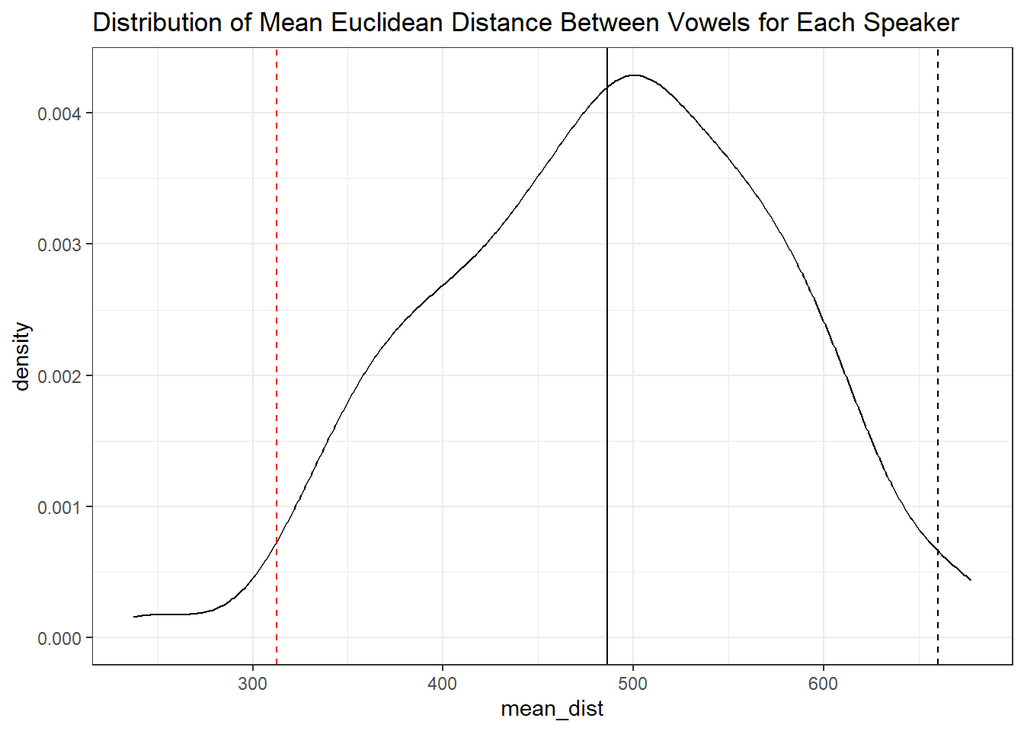

Figure 5.1: Distribution of mean euclidean distance between vowels for each speaker

```r
#calculate speaker means and sd
speaker_means <- Quakebox_filtered %>%
  group_by(Speaker, Vowel) %>%
  summarise(
    n = n(),
    F1_mean = mean(F1_50),
    F2_mean = mean(F2_50),
    F1_sd = sd(F1_50),
    F2_sd = sd(F2_50)
  )

#calculate euclidean distances between vowel means
speaker_distances <- speaker_means %>%
  mutate(
    #calculate the euclidean distance matrix between the vowel means for each
    #speaker
    Dist = colMeans(
      as.matrix(dist(cbind(F1_mean, F2_mean)))
    )
  ) %>%
  ungroup() %>%

  #calculate the mean distance across all vowels (by speaker)
  group_by(Speaker) %>%
  summarise(
    mean_dist = mean(Dist)
  ) %>%

  #create a new variable for plotting
  mutate(
    Speaker_dist = paste(round(mean_dist, 2), Speaker)
  )

#plot the distribution
ggplot(
  speaker_distances,
  aes(x = mean_dist)
  ) +
  geom_density() +
  geom_vline(
    xintercept = mean(speaker_distances$mean_dist),
    linetype = 1
  ) +
  geom_vline(
    xintercept = mean(speaker_distances$mean_dist) +
      2*sd(speaker_distances$mean_dist),
    linetype = 2
  ) +
  geom_vline(
    xintercept = mean(speaker_distances$mean_dist) -
      2*sd(speaker_distances$mean_dist),
    linetype = 2,
    colour = "red") +
  theme_bw() +
  labs(
    title = "Distribution of Mean Euclidean Distance Between Vowels for Each Speaker",
    xlab = "Mean Euclidian Distance",
    ylab = "Density"
  )
```

```r
#filter speakers who are -2 SDs from the mean euclidean distance
outlier_speakers <- speaker_means %>%
  inner_join(speaker_distances) %>%
  filter(
    mean_dist < mean(speaker_distances$mean_dist) -
      2*sd(speaker_distances$mean_dist)
  )

#plot the outlier speakers vowel spaces
outlier_speakers_plot <- Quakebox_filtered %>%
  filter(Speaker %in% outlier_speakers$Speaker) %>%
  inner_join(outlier_speakers) %>%
  arrange(mean_dist) %>%
  ggplot(
    aes(x = F2_50, y = F1_50, colour = Vowel)
  ) +
  geom_point(size = 0.02, alpha = 0.5) +
  stat_ellipse(level = 0.67) +
  geom_text(
    data = outlier_speakers,
    aes(
      x = F2_mean,
      y = F1_mean,
      label = Vowel
    ),
    size = 2) +
  scale_x_reverse() +
  scale_y_reverse() +
  theme_bw() +
  theme(legend.position = "none") +
  labs(
    title = "Low Mean Euclidean Distance Vowel Spaces"
  )
```

We look at the vowel spaces of each of the speakers in the bottom tail of this distribution to see if there has been some problem extracting their vowels.

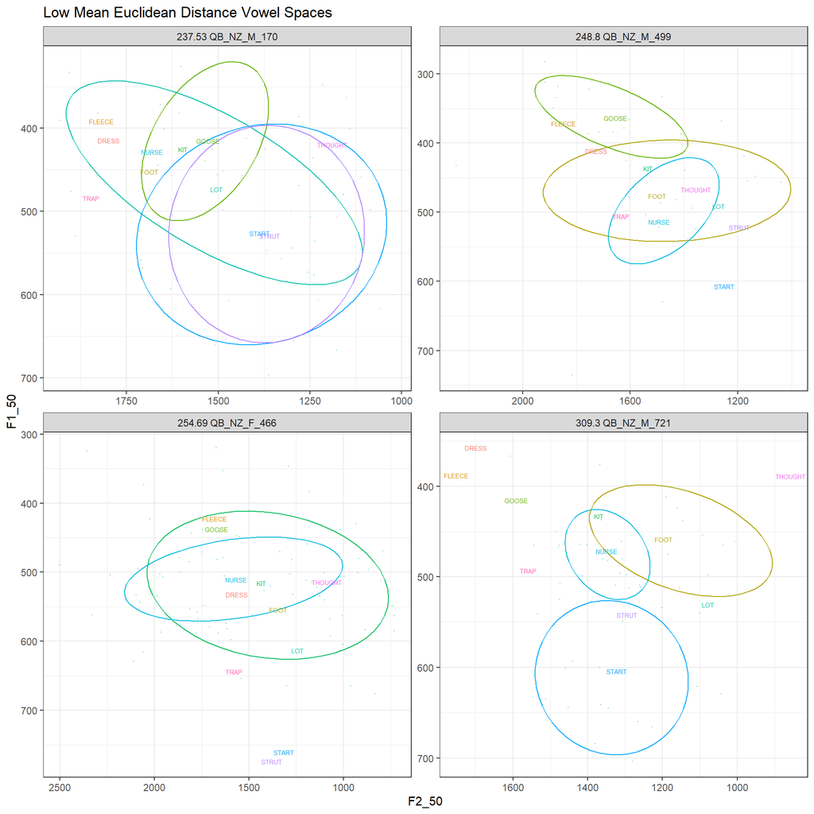

Figure 5.2: Low mean distance speaker vowel spaces.

```r
outlier_speakers_plot + facet_wrap(vars(Speaker_dist), scales="free")
```

We are here looking for completely implausible vowel spaces for NZE speakers. All of the speakers in the bottom tail of between-vowel Euclidean distance are within the realm of possibility for NZE speakers (Figure 5.2). We will keep them all in the data set. Compare the results of this step in [Brand et al. 2021](https://nzilbb.github.io/Covariation_monophthongs_NZE/Covariation_monophthongs_filtering_anon.html#speaker_outlier_removal).

At this point it is convenient to reorder the dataset to ensure that it is organised by the `Speaker` column and in the order in which the tokens appear in each speaker’s monologue. We will also remove extra variables generated in the filtering process.

```r
Quakebox_filtered <- Quakebox_filtered %>%
  # remove variables created for filtering purposes
  select(
    -c(
      "outlier",
      "n",
      "mean_F1",
      "mean_F2",
      "sd_F1",
      "sd_F2",
      "min_F1",
      "min_F2",
      "max_F1",
      "max_F2"
    )
  ) %>%
  arrange(Speaker, Target.segments.start) # order data by speaker and by time.
```

We save the resulting dataset. **NB:** To actually output set `eval` to TRUE in the block options.

```r
write_rds(
  Quakebox_filtered, here('processed_data', 'Quakebox_filtered.rds')
)
```

# 6 Data Description and Visualisation

```r
# Flow chart generated using the DiagrammeR package.
flow_chart <- mermaid(
  diagram = glue("
  graph TB

  A(Extract data from LaBB-CAT: {count_orig} tokens) -->
    B(Remove stopwords and hesitations: {count_load} tokens)
  B --> C(Filter by stress and length: {count_filter} tokens)
  C --> D(Filter tokens preceeding liquids: {count_liquid} tokens)
  D --> E(Remove outliers: {count_outlier} tokens)

  "),
  width = 800
)

flow_chart
```

[interactive chart not shown]

Figure 6.1: Filtering flow chart

Having filtered the data, we look at the distribution of tokens across vowel categories and other variables.

First, we categorise by vowel type.

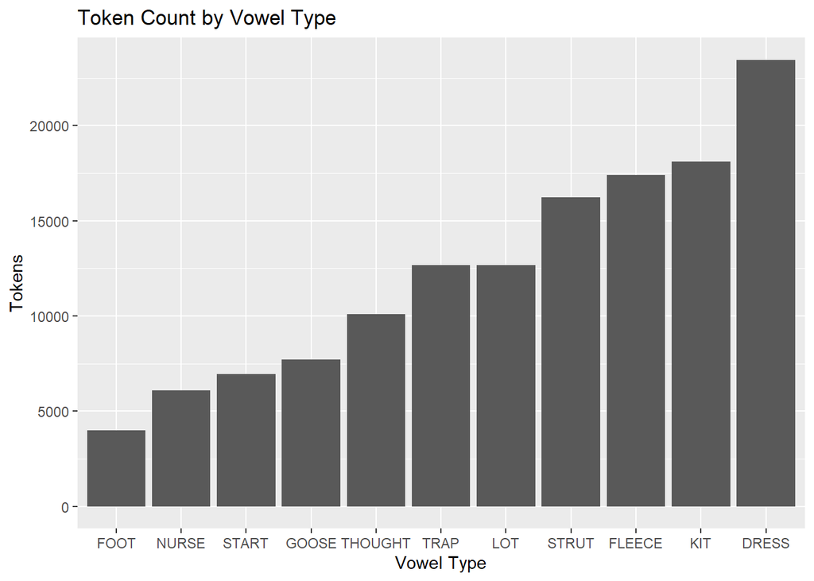

Figure 6.2: Tokens by Vowel Type

```r
plot_tokens_by_category <- function(category, title) {
  category <- sym(category)
  Quakebox_filtered %>%
    group_by(
      !!category
    ) %>%
    summarise(
      n = n()
    ) %>%
    mutate(
      !!category := fct_reorder(!!category, n)
    ) %>%
    ggplot(
      aes(
        x = !!category,
        y = n
      )
    ) +
    geom_col() +
    labs(
      title = glue("Token Count by {title}"),
      y = "Tokens",
      x = glue("{title}")
    )
}

vowel_type_plot <- plot_tokens_by_category("Vowel", "Vowel Type")

vowel_type_plot
```

By gender:

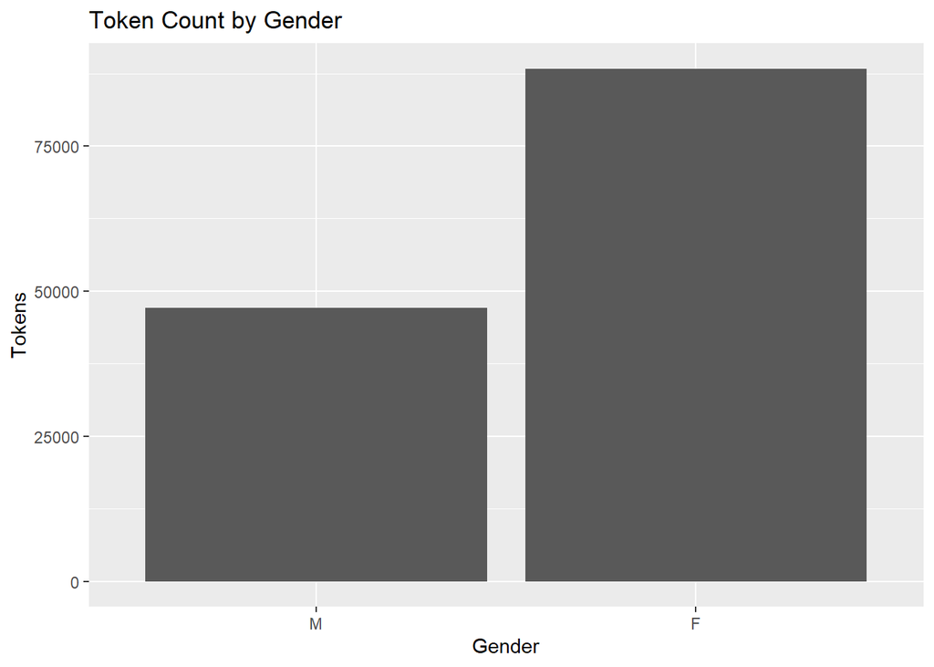

Figure 6.3: Tokens by Gender

```r
gender_type_plot <- plot_tokens_by_category("participant_gender", "Gender")

gender_type_plot
```

By ethnicity:

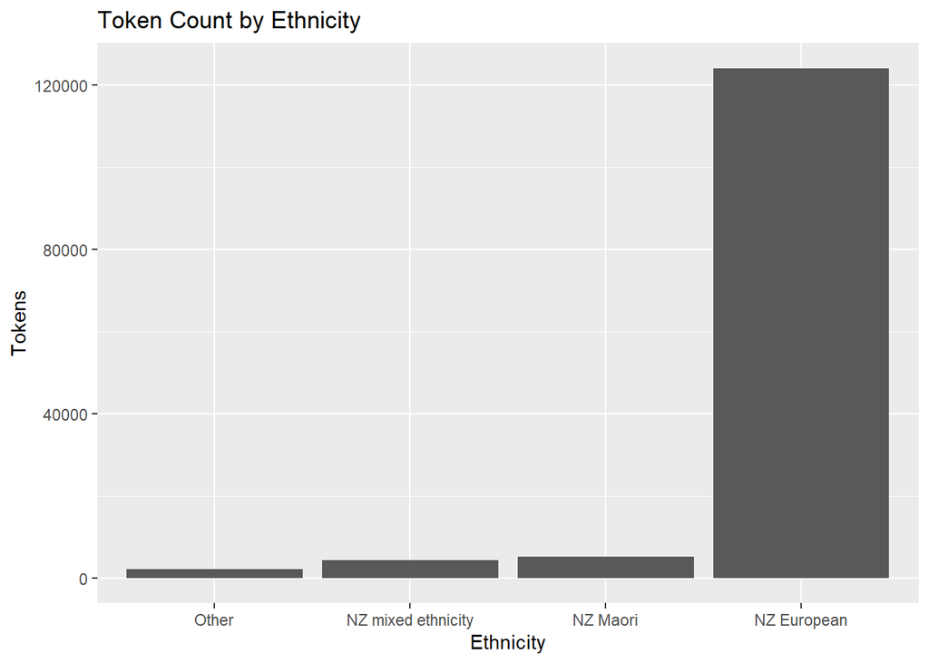

Figure 6.4: Tokens by Ethnicity

```r
ethnicity_plot <- plot_tokens_by_category("participant_nz_ethnic", "Ethnicity")

ethnicity_plot
```

By age:

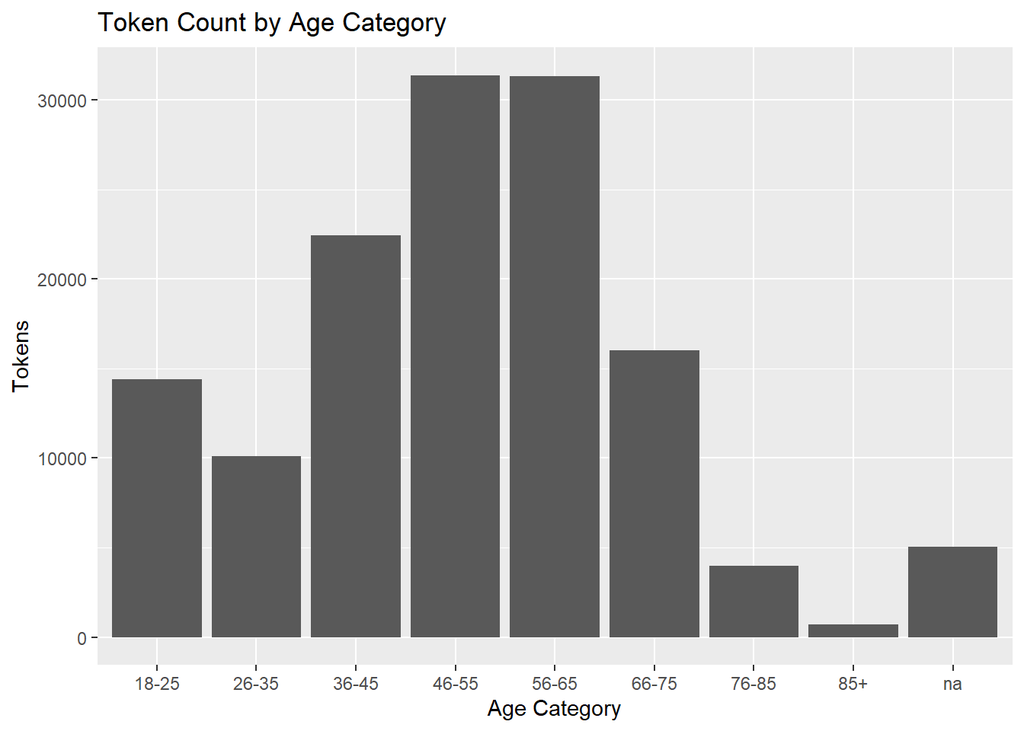

Figure 6.5: Tokens by age category

```r
age_plot <- Quakebox_filtered %>%
    group_by(
      participant_age_category
    ) %>%
    summarise(
      n = n()
    ) %>%
    ggplot(
      aes(
        x = participant_age_category,
        y = n
      )
    ) +
    geom_col() +
    labs(
      title = "Token Count by Age Category",
      y = "Tokens",
      x = "Age Category"
    )

age_plot
```

The plots above should not be surprising given the nature of the corpus.

The resulting dataset has the following variables:

```r
Quakebox_filtered <- Quakebox_filtered %>%
  mutate(
    following_segment_category = as.character(following_segment_category)
  )

var_description = c(
  "Anonymized word identification.",
  "Anonymized speaker.",
  "Partipant gender (m/f).",
  "Participant age category (9 levels).",
  "Participant ethnicity.",
  "Participant ethnicity, New Zealand categories. Divided into NZ European, Māori, mixed, and other.",
  "Languages spoken by participant.",
  "Speaker articulation rate (average).",
  "LaBB-CAT match ID for segment. This enables a researcher with access to the LaBB-CAT instance to retreive the original non-anonymised data.",
  "LaBB-CAT match ID for target. This enables a researcher with access to the LaBB-CAT instance to retreive the original non-anonymised data.",
  "LaBB-CAT URL to access original data.",
  "Stress coding for token.",
  "CELEX frequency of word.",
  "Corpus frequency of word.",
  "Time stamp of token onset (seconds).",
  "Vowel type.",
  "Duration of token (seconds).",
  "Mid point F1 reading, generated by Praat.",
  "Mid point F2 reading, generated by Praat.",
  "Length of phonological transcription of word in which token appears.",
  "Mean pitch (hz).",
  "Minimum pitch of token (hz).", # Check "of token".
  "Maximum pitch of token (hz).",
  "Duration of participant speech in recording (seconds).",
  "Number of words in participant monologue.",
  "Articulation rate of utterance in which token is located (seconds).",
  "Segment which follows vowel token.",
  "Maximum amplitude of word in which token located, generated by Praat.",
  "Topical annotations.",
  "Category of segment which follows vowel token."
)

variables_tables = tibble(
    Variable = names(Quakebox_filtered),
    Description = var_description
  ) %>%
  mutate(
    Type = map_chr(Variable, ~ typeof(Quakebox_filtered[[.x]]))
  ) %>%
  mutate(
    `Distinct Values` = map_chr(Variable, ~ n_distinct(Quakebox_filtered[[.x]])),
    `Distinct Values` = if_else(Type == "character", `Distinct Values`, "NA")
  ) %>%
  arrange(Type) %>%
  kable(
    format = "html",
    table.attr = "style = \"border: 1px solid; margin-bottom: 15px;\""
  )

variables_tables
```

| Variable | Description | Type | Distinct Values |
| --- | --- | --- | --- |
| word | Anonymized word identification. | character | 6447 |
| Speaker | Anonymized speaker. | character | 280 |
| participant_gender | Partipant gender (m/f). | character | 2 |
| participant_age_category | Participant age category (9 levels). | character | 9 |
| participant_ethnicity | Participant ethnicity. | character | 2 |
| participant_nz_ethnic | Participant ethnicity, New Zealand categories. Divided into NZ European, Māori, mixed, and other. | character | 4 |
| participant_languages_spoken | Languages spoken by participant. | character | 14 |
| MatchId | LaBB-CAT match ID for segment. This enables a researcher with access to the LaBB-CAT instance to retreive the original non-anonymised data. | character | 135407 |
| TargetId | LaBB-CAT match ID for target. This enables a researcher with access to the LaBB-CAT instance to retreive the original non-anonymised data. | character | 135407 |
| URL | LaBB-CAT URL to access original data. | character | 133180 |
| Target.stress | Stress coding for token. | character | 4 |
| Vowel | Vowel type. | character | 11 |
| following_segment | Segment which follows vowel token. | character | 39 |
| type | Topical annotations. | character | 29 |
| following_segment_category | Category of segment which follows vowel token. | character | 3 |
| participant_speaker.articulation.rate | Speaker articulation rate (average). | double | NA |
| Target.segments.start | Time stamp of token onset (seconds). | double | NA |
| vowel_duration | Duration of token (seconds). | double | NA |
| participant_duration | Duration of participant speech in recording (seconds). | double | NA |
| utterance.articulation.rate | Articulation rate of utterance in which token is located (seconds). | double | NA |
| intensity_max | Maximum amplitude of word in which token located, generated by Praat. | double | NA |
| Target.celex.frequency | CELEX frequency of word. | integer | NA |
| Target.frequency..corpus. | Corpus frequency of word. | integer | NA |
| F1_50 | Mid point F1 reading, generated by Praat. | integer | NA |
| F2_50 | Mid point F2 reading, generated by Praat. | integer | NA |
| phonological_length | Length of phonological transcription of word in which token appears. | integer | NA |
| MeanPitch | Mean pitch (hz). | integer | NA |
| MinPitch | Minimum pitch of token (hz). | integer | NA |
| MaxPitch | Maximum pitch of token (hz). | integer | NA |
| participant_word.count | Number of words in participant monologue. | integer | NA |

Not all of these variables are used in our analysis. For instance, we do not use word frequency data. However, they may be of use for anyone who wishes to engage in further analysis or criticism of our results.

We also generate counts for **Table 1** and **Table 2** in the paper.

```r
# Speaker level counts (Table 1 in paper)

desired_variables <- c(
  "participant_age_category", "participant_gender", "participant_nz_ethnic",
  "length_categories"
)

Quakebox_filtered <- Quakebox_filtered %>%
  # generate length as in 'interval_representation'
  group_by(Speaker) %>%
  mutate(
    recording_length = max(Target.segments.start)
  ) %>%
  ungroup() %>%
  mutate(
    length_categories = cut(
      recording_length,
      breaks = c(0, 600, 1200, max(recording_length)),
      labels = c("short (-10m)", "medium (10-20m)", "long (20m+)")
    ),
    length_categories = fct_relevel(
      length_categories,
      c("short (-10m)", "medium (10-20m)", "long (20m+)")
    )
  )


for (var_name in desired_variables) {
  Quakebox_filtered %>%
    group_by(.data[[var_name]]) %>%
    summarise(
      n = n_distinct(Speaker)
    ) %>%
    print()
}
```

```
## # A tibble: 9 × 2
##   participant_age_category     n
##   <chr>                    <int>
## 1 18-25                       41
## 2 26-35                       19
## 3 36-45                       41
## 4 46-55                       68
## 5 56-65                       55
## 6 66-75                       34
## 7 76-85                       11
## 8 85+                          3
## 9 na                           8
## # A tibble: 2 × 2
##   participant_gender     n
##   <chr>              <int>
## 1 F                    186
## 2 M                     94
## # A tibble: 4 × 2
##   participant_nz_ethnic     n
##   <chr>                 <int>
## 1 NZ European             257
## 2 NZ Maori                  8
## 3 NZ mixed ethnicity        9
## 4 Other                     6
## # A tibble: 3 × 2
##   length_categories     n
##   <fct>             <int>
## 1 short (-10m)        162
## 2 medium (10-20m)      84
## 3 long (20m+)          34
```

```r
# Token level counts (Table 2 in paper).

Quakebox_filtered %>%
  group_by(Vowel) %>%
  summarise(
    n = n()
  )
```

| Vowel | n |
| --- | --- |
| DRESS | 23453 |
| FLEECE | 17404 |
| FOOT | 3998 |
| GOOSE | 7704 |
| KIT | 18117 |
| LOT | 12681 |
| NURSE | 6082 |
| START | 6948 |
| STRUT | 16241 |
| THOUGHT | 10101 |

[output cut: 1 more lines]

The next step in our analysis can be found in the R Markdown file `interval_representation.Rmd`. In it, we divide speaker monologues into intervals of even length within which we calculate vowel spaces.

[^1]: The removed stopwords were: ‘a’, ‘ah’, ‘ahh’, ‘am’, ‘an’, ‘and’, ‘are’, “aren’t”, ‘as’, ‘at’, ‘aw’, ‘because’, ‘but’, ‘could’, ‘do’, “don’t”, ‘eh’, ‘for’, ‘from’, ‘gonna’, ‘had’, ‘has’, ‘have’, ‘he’, “he’s”, ‘her’, ‘high’, ‘him’, ‘huh’, ‘i’, “i’ll”, “i’m”, “i’ve”, “i’d”, ‘in’, ‘into’, ‘is’, ‘it’, “it’s”, ‘its’, ‘just’, ‘mean’, ‘my’, ‘nah’, ‘not’, ‘of’, ‘oh’, ‘on’, ‘or’, ‘our’, ‘says’, ‘she’, “she’s”, ‘should’, ‘so’, ‘than’, ‘that’, “that’s”, ‘the’, ‘them’, ‘there’, “there’s”, ‘they’, ‘this’, ‘to’, ‘uh’, ‘um’, ‘up’, ‘was’, “wasn’t”, ‘we’, ‘were’, ‘what’, ‘when’, ‘which’, ‘who’, ‘with’, ‘would’, ‘yeah’, ‘you’, “you’ve”